# Peer assigment practical machine learning course

ramiro villegas

Wednesday, June 17, 2015

### Executive summary.

I want to show with this work the practical use of machine learning with physical data obtained with IMUs ( inertial electronic units) to classify several ways to do an exercise.

### Cleaning data.

1. Replace all #DIV/0! and empty data with NA.
2. Remove all columns with less than 20% of data.
3. Remove rows that have NA’s
4. Delete **new_window** and **num_windows** because this is not physical data.

```r
library(caret)
library(randomForest)
setwd('D:\\rvillegas\\Mio\\coursera\\pml\\wd\\pml_peer_assigment')
data<-data.frame(read.csv('pml-training.csv',header=TRUE, stringsAsFactor=FALSE))
data_test<-data.frame(read.csv('pml-testing.csv',header=TRUE, stringsAsFactor=FALSE))
#Names of columns is different fron training and testing, but the position is the same
data$classe<-as.factor(data$classe)
#nf: Total rows
nf<-dim(data)[1]
#fc: Factor to select the number of rows, to test methods I use 0.1,
#    to final evaluation with selected method I use 1.0
fc<-1.0

filas<-as.integer(runif(nf*fc,1,nf))
data<-data[filas,]

#Split the data in training and testing
intrain<-createDataPartition(y=data$classe,p=0.75,list=FALSE)
tr<-data[intrain,]
te<-data[-intrain,]

# convert #DIV/0! and empty in NA's

tr[tr=="#DIV/0!"]<-NA
tr[tr==""]<-NA
nc<-dim(tr)[2]

# extract only the selected columns

tr<-tr[,8:nc]
nc<-dim(te)[2]
te<-te[,8:nc]

# Count the NA per column and delete the columns with less than 20% of data
x<-apply(tr,2,function(x) sum(is.na(x)))
nf<-dim(tr)[1]
limite<-nf*0.2
x<-x[x<limite]
#Select only the columns without NA values
n<-names(x)
tr<-tr[n]
te<-te[n]
#Delete all files with NA values.
tr<-na.omit(tr)
te<-na.omit(te)
```

### Select the best machine learning method for this data.

I select 10% of the data to choose accuracy method. the code is on file **pa_pml.Rmd** in this repostery. The results are:

| Method | Pre process | Accuracy |
| --- | --- | --- |
| rpart | No | 0.493 |
| rpart | pca | 0.391 |
| rpart | center , scale | 0.493 |
| random forest | pca | 0.840 |
| random forest | No | 0.947 |
| Boosting | pca | 0.724 |
| Boosting | No | 0.937 |

The best method is random forest without pre process.

### Training

The data was splitted 75% for training, 25% for validation. The training was spent 14 hours in my computer. I used The following code:

```r
modelFit<-train(tr$classe ~ ., data=tr[-53],method="rf",prox=TRUE)
cm3<-confusionMatrix(te$classe,predict(modelFit,te[-53]))
mF3<-modelFit
```

### Results.

#### Confusion maxtrix.

|  | A | B | C | D | E | Error |
| --- | --- | --- | --- | --- | --- | --- |
| A | 1379 | 0 | 0 | 0 | 0 | 0.0000 |
| B | 7 | 947 | 3 | 0 | 0 | 0.0104 |
| C | 0 | 3 | 853 | 1 | 0 | 0.0047 |
| D | 0 | 0 | 1 | 816 | 0 | 0.0012 |
| E | 0 | 0 | 1 | 2 | 892 | 0.0034 |

The accuracy is 0.996

#### Errors vs number of trees

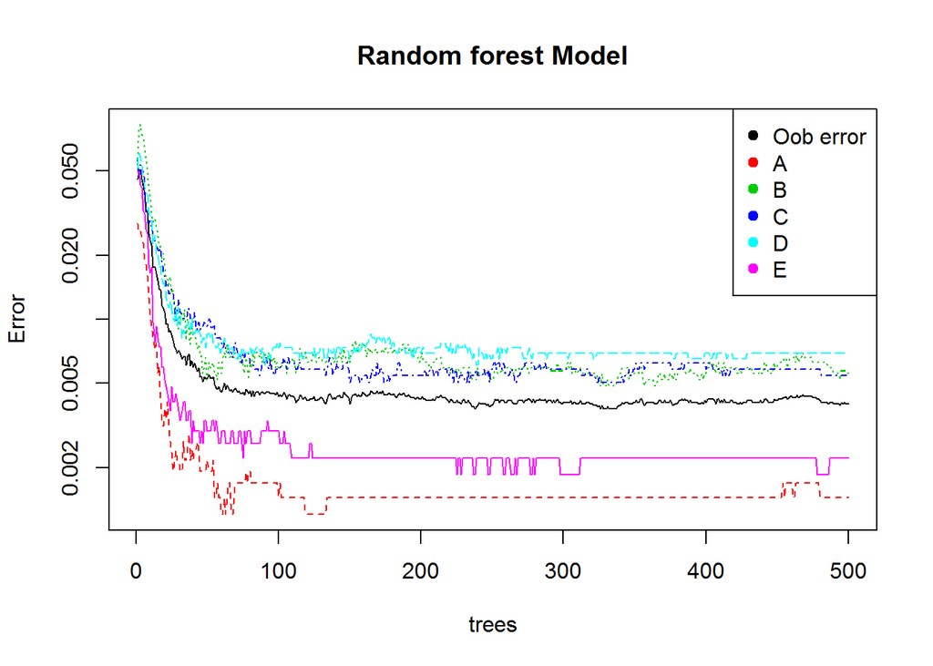

This graphics show the # of trees vs errors of **Out of bag error** and each classification level. With this graphic can be concluded that with only 150 trees the model has high accuracy too. I run a new model with training function of randomForest package and I got a big surprise: the training only took four minutes against 14 hours delayed training with 500 trees in Caret Package.

The code was:

```r
rf<-randomForest(y=tr$classe,x=tr[-53],ntree=150,prox=TRUE)
```

I test the 20 testing samples of **peer assigment submission** and the answer is the same with both models.

### Variable importance.

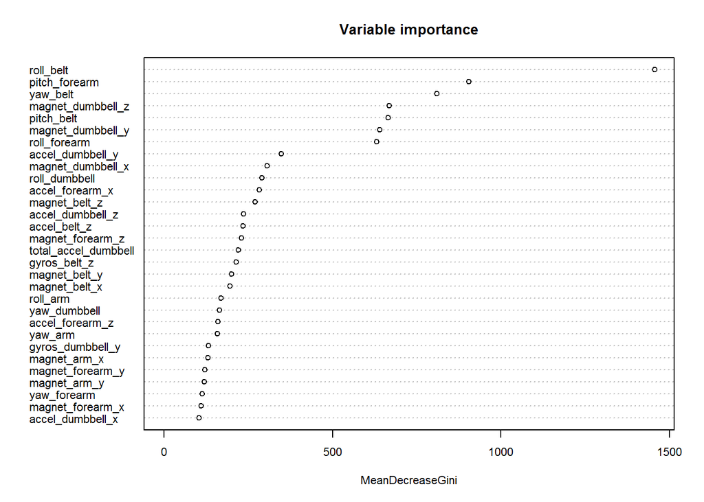

This graphic show the order of importance of variables.

## Conclusion.

Doing this work I learned that this method can be very useful when there are many variables and a lot of data , but the default values used in the Caret package may have been revised like **ntree**, because changing it the process time it is greatly decreased without decrease the accuracy.